## Background Introduction

Using devices such as Jawbone Up, Nike FuelBand, and Fitbit it is now possible to collect a large amount of data about personal activity relatively inexpensively. These type of devices are part of the quantified self movement - a group of enthusiasts who take measurements about themselves regularly to improve their health, to find patterns in their behavior, or because they are tech geeks. One thing that people regularly do is quantify how much of a particular activity they do, but they rarely quantify how well they do it.

The goal of the project is to try to predict the classification of each activity based on recorded input data.

## Reproducibility

The following libraries were used for the project.

```r
library(caret)
library(rpart)
```

```r
library(rpart.plot)
library(randomForest)
library(corrplot)
```

To ensure reproducibility, the following seed was used.

```r
set.seed(10000) # For reproducibile purpose
```

## Data Preprocessing

### 1.Download the Data

```r
trainUrl <- "https://d396qusza40orc.cloudfront.net/predmachlearn/pml-training.csv"
testUrl <- "https://d396qusza40orc.cloudfront.net/predmachlearn/pml-testing.csv"
trainFile <- "./data/training.csv"
testFile  <- "./data/testing.csv"
if (!file.exists("./data")) {
  dir.create("./data")
}
if (!file.exists(trainFile)) {
  download.file(trainUrl, destfile=trainFile)
}
if (!file.exists(testFile)) {
  download.file(testUrl, destfile=testFile)
}
```

### 2. Read the 2 csv files into 2 dataframes.

```r
training <- read.csv(trainFile)
testing <- read.csv(testFile)
dim(training)
```

```
## [1] 19622   160
```

```r
dim(testing)
```

```
## [1]  20 160
```

### 3. Cleaning the Data

Remove columns that contain NA missing values.

```r
training <- training[, colSums(is.na(training)) == 0]
testing <- testing[, colSums(is.na(testing)) == 0]
str(training)
```

```
## 'data.frame':    19622 obs. of  93 variables:
##  $ X                      : int  1 2 3 4 5 6 7 8 9 10 ...
##  $ user_name              : Factor w/ 6 levels "adelmo","carlitos",..: 2 2 2 2 2 2 2 2 2 2 ...
##  $ raw_timestamp_part_1   : int  1323084231 1323084231 1323084231 1323084232 1323084232 1323084232 1323084232 1323084232 1323084232 1323084232 ...
##  $ raw_timestamp_part_2   : int  788290 808298 820366 120339 196328 304277 368296 440390 484323 484434 ...
##  $ cvtd_timestamp         : Factor w/ 20 levels "02/12/2011 13:32",..: 9 9 9 9 9 9 9 9 9 9 ...
##  $ new_window             : Factor w/ 2 levels "no","yes": 1 1 1 1 1 1 1 1 1 1 ...
##  $ num_window             : int  11 11 11 12 12 12 12 12 12 12 ...
##  $ roll_belt              : num  1.41 1.41 1.42 1.48 1.48 1.45 1.42 1.42 1.43 1.45 ...
##  $ pitch_belt             : num  8.07 8.07 8.07 8.05 8.07 8.06 8.09 8.13 8.16 8.17 ...
##  $ yaw_belt               : num  -94.4 -94.4 -94.4 -94.4 -94.4 -94.4 -94.4 -94.4 -94.4 -94.4 ...
##  $ total_accel_belt       : int  3 3 3 3 3 3 3 3 3 3 ...
##  $ kurtosis_roll_belt     : Factor w/ 397 levels "","-0.016850",..: 1 1 1 1 1 1 1 1 1 1 ...
##  $ kurtosis_picth_belt    : Factor w/ 317 levels "","-0.021887",..: 1 1 1 1 1 1 1 1 1 1 ...
##  $ kurtosis_yaw_belt      : Factor w/ 2 levels "","#DIV/0!": 1 1 1 1 1 1 1 1 1 1 ...
```

[output cut: 79 more lines]

Remove columns that are mainly for recording purposes and are unrelated to movement

```r
classe <-training$classe
trainRemove <- grepl("^X|timestamp|window", names(training))
training <- training[, !trainRemove]
trainingClean <- training[, sapply(training, is.numeric)]
trainingClean$classe <- classe
testRemove <- grepl("^X|timestamp|window", names(testing))
testing <- testing[, !testRemove]
testingCleaned <- testing[, sapply(testing, is.numeric)]
```

### Partitioning the training set into 2

Here we will parition the training set into a pure training data set (60%) and a validation data set (40%).

```r
inTrain <- createDataPartition(y=training$classe, p=0.6, list=FALSE)
myTraining <- trainingClean[inTrain, ];
myTesting <- trainingClean[-inTrain, ]
dim(myTraining);
```

```
## [1] 11776    53
```

```r
dim(myTesting)
```

```
## [1] 7846   53
```

## Data Modeling

### 1. Predictive Model: Decision Tree

We fit a predictive model using the Decision Tree algorithm.

```r
modFitDecisionTree <- rpart(classe ~ ., data=myTraining, method="class")
```

Prediction & Performace:

```r
predictionsDecisionTree <- predict(modFitDecisionTree, myTesting, type = "class")
confusionMatrix(predictionsDecisionTree, myTesting$classe)
```

```
## Confusion Matrix and Statistics
##
##           Reference
## Prediction    A    B    C    D    E
##          A 2053  339   33  125   91
##          B   71  873  135   53  156
##          C   42  110 1014  191  137
##          D   34  110   91  838  124
##          E   32   86   95   79  934
##
## Overall Statistics
##
##                Accuracy : 0.728
##                  95% CI : (0.718, 0.7378)
##     No Information Rate : 0.2845
##     P-Value [Acc > NIR] : < 2.2e-16
##
##                   Kappa : 0.6538
##  Mcnemar's Test P-Value : < 2.2e-16
##
## Statistics by Class:
##
##                      Class: A Class: B Class: C Class: D Class: E
## Sensitivity            0.9198   0.5751   0.7412   0.6516   0.6477
## Specificity            0.8953   0.9344   0.9259   0.9453   0.9544
## Pos Pred Value         0.7774   0.6778   0.6787   0.7001   0.7618
## Neg Pred Value         0.9656   0.9016   0.9443   0.9326   0.9233
## Prevalence             0.2845   0.1935   0.1744   0.1639   0.1838
## Detection Rate         0.2617   0.1113   0.1292   0.1068   0.1190
## Detection Prevalence   0.3366   0.1642   0.1904   0.1526   0.1563
## Balanced Accuracy      0.9075   0.7548   0.8336   0.7985   0.8011
```

### 2. Predictive Model: Random Forest

We fit a predictive model using Random Forest algorithm. We will use 5-fold cross validation when applying the algorithm.

```r
controlRf <- trainControl(method="cv", 5)
modFitRandomforest <- train(classe ~ ., data=myTraining, method="rf", trControl=controlRf, ntree=250)
modFitRandomforest
```

```
## Random Forest
##
## 11776 samples
##    52 predictor
##     5 classes: 'A', 'B', 'C', 'D', 'E'
##
## No pre-processing
## Resampling: Cross-Validated (5 fold)
## Summary of sample sizes: 9421, 9421, 9422, 9420, 9420
## Resampling results across tuning parameters:
##
##   mtry  Accuracy   Kappa      Accuracy SD  Kappa SD
##    2    0.9874323  0.9840997  0.001980469  0.002506329
##   27    0.9880270  0.9848534  0.002705280  0.003422079
##   52    0.9798751  0.9745411  0.003553735  0.004490160
##
## Accuracy was used to select the optimal model using  the largest value.
## The final value used for the model was mtry = 27.
```

Prediction & Performace:

```r
predictionsRandomforest <- predict(modFitRandomforest, myTesting)
confusionMatrix(myTesting$classe, predictionsRandomforest)
```

```
## Confusion Matrix and Statistics
##
##           Reference
## Prediction    A    B    C    D    E
##          A 2230    1    1    0    0
##          B   12 1500    6    0    0
##          C    0   15 1349    4    0
##          D    0    0   14 1271    1
##          E    0    0    1    5 1436
##
## Overall Statistics
##
##                Accuracy : 0.9924
##                  95% CI : (0.9902, 0.9942)
##     No Information Rate : 0.2858
##     P-Value [Acc > NIR] : < 2.2e-16
##
##                   Kappa : 0.9903
##  Mcnemar's Test P-Value : NA
##
## Statistics by Class:
##
##                      Class: A Class: B Class: C Class: D Class: E
## Sensitivity            0.9946   0.9894   0.9840   0.9930   0.9993
## Specificity            0.9996   0.9972   0.9971   0.9977   0.9991
## Pos Pred Value         0.9991   0.9881   0.9861   0.9883   0.9958
## Neg Pred Value         0.9979   0.9975   0.9966   0.9986   0.9998
## Prevalence             0.2858   0.1932   0.1747   0.1631   0.1832
## Detection Rate         0.2842   0.1912   0.1719   0.1620   0.1830
## Detection Prevalence   0.2845   0.1935   0.1744   0.1639   0.1838
## Balanced Accuracy      0.9971   0.9933   0.9905   0.9953   0.9992
```

```r
accuracy <- postResample(predictionsRandomforest, myTesting$classe)
accuracy
```

```
##  Accuracy     Kappa
## 0.9923528 0.9903256
```

```r
oose <- 1 - as.numeric(confusionMatrix(myTesting$classe, predictionsRandomforest)$overall[1])
oose
```

```
## [1] 0.007647209
```

Choose the model derivied using the randomForest algorithm as it has higher accuracy.

## Predicting using Test Data Set

1. Remove problem_id

```r
result <- predict(modFitRandomforest, testingCleaned[, -length(names(testingCleaned))])
result
```

```
##  [1] B A B A A E D B A A B C B A E E A B B B
## Levels: A B C D E
```

## Appendix: Figures

1. Decision Tree Visualization

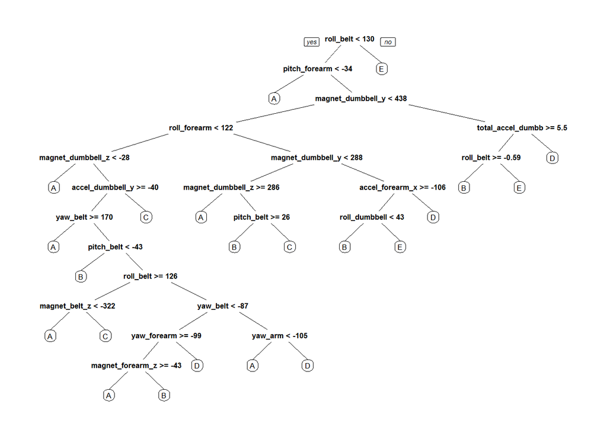

```r
prp(modFitDecisionTree) # fast plot
```

2. Correlation Matrix Visualization

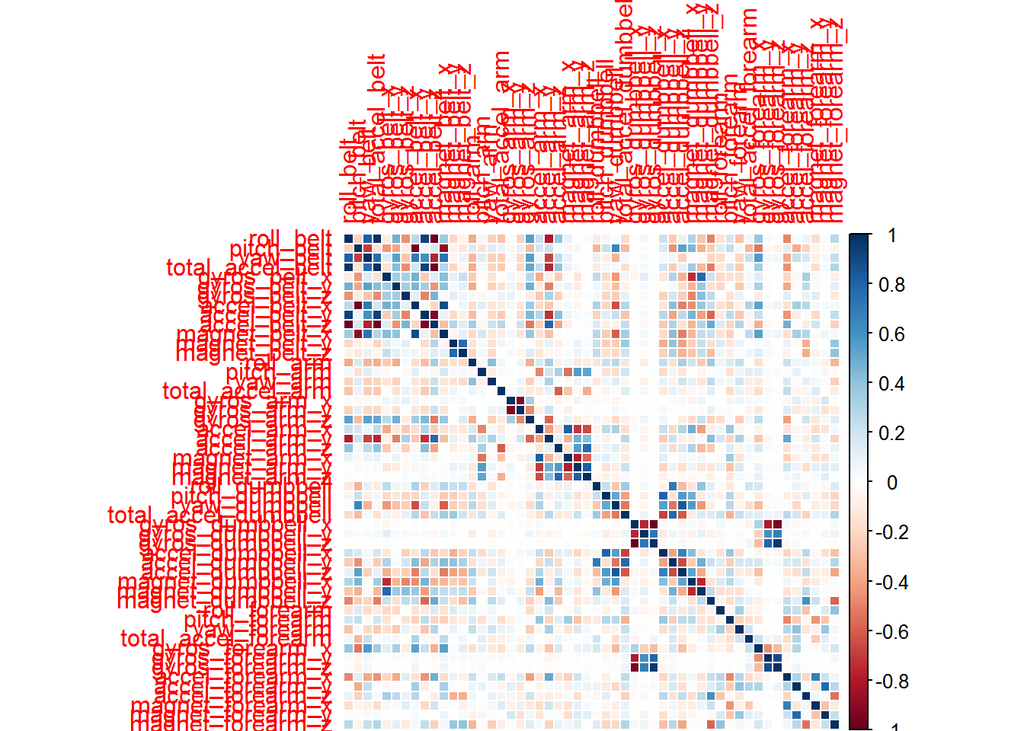

```r
corrPlot <- cor(myTraining[, -length(names(myTraining))])
corrplot(corrPlot, method="color")
```